# Homework_2_jonasxie

## SI 670 Applied Machine Learning, HW 2 (Due Tuesday Sep 16, 2025 11:59 PM)

**IMPORTANT**: please name your submitted file `si670f25_hw2_youruniqname.ipynb` when submitting on Gradescope

As a reminder, the notebook code you submit must be your own work. Feel free to discuss general approaches to the homework with classmates. If you end up forming more of a team discussion on multiple questions, please include the names of the people you worked with at the top of your notebook file.

**Your name:** Zhonghan Xie

**Your uniqname:** jonasxie

**Collaborators (if any):**

**Questions 1-3 are in SI 670 - Problem Set 2**

## Problem 4 (13 points)

Your goal for this question is to run a simple linear regression on the data, and investigate its performance. Note that this question has multiple parts.

First you need to run the following block, which sets up the training and test datasets to be used for this question.

```python
import numpy as np

# We fix the state of the random number generator here in order to maintain consistency in the results
rs = np.random.RandomState(0)
X_train = rs.uniform(size = (100, 1))
y_train = 5 * X_train + 8
X_test = rs.uniform(size = (20, 1))
y_test = 7 * X_test + 1
```

Now, write a function that takes in training data as input, and fits a line to the data using a linear regression model. Your function should return the linear regression model.

```python
def fit_line(X_train, y_train):
    from sklearn.linear_model import LinearRegression

    # Your code: fit a linear regression model to the input data, name it `linreg'
    linreg = LinearRegression().fit(X_train, y_train)
    # Return the linear regression model you created
    return linreg
```

Run the following block of code in order to (1) compute the the $R^2$ (coefficient of determination) regression score on both training and test datasets, and then (2) plot the training and test datasets in the same figure, marked by different colors (blue for training data, red for test data).

```
R-squared score (training): 1.000
R-squared score (test): -11.533
```

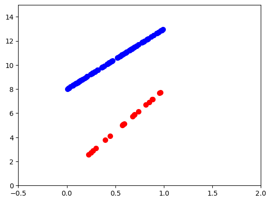

```python
# Fit a line to the dataset we generated at the beginning of this problem using your function
linreg = fit_line(X_train, y_train)

# Compute R^2 score of your model on training and test sets
print('R-squared score (training): {:.3f}'
     .format(linreg.score(X_train, y_train)))
print('R-squared score (test): {:.3f}'
     .format(linreg.score(X_test, y_test)))

# Plot the training and test datasets in the same figure marked by different colors
import matplotlib.pyplot as plt
fig = plt.figure()
plt.xlim(-0.5, 2)
plt.ylim(0, 15)
plt.scatter(X_train, y_train, c='blue', marker='o', s=50) # Blue points are from training dataset
plt.scatter(X_test, y_test, c='red', marker='o', s=50) # Red points are from test dataset
```

What does the $R^2$ score of your model on the two datasets tell you about the performance of your model? Using the plot of the two datasets, why do you think we get these $R^2$ scores? Please provide your answer in the text cell below.

**Your answer to problem 4 here**: We have a overfitting problem in our model: the training accuracy is very high and the test accuracy is extremely low (even lower than 0). It is very likely due to the very different data generating processes in the training and testing datasets. And both the DGPs are fully linear. The training model can hardly be generalized to other DGPs.

### Question 5 (20 points) Bias and Variance

## (a) 10 points

Your task is to investigate the influence of different regularization parameters on the coefficients of a ridge regression model.

Given 10 points around the function $y = x^2 + 2x + 1$. You are asked to train a linear ridge regression with degree 6 polynomial features. And run it with different regularization parameters $\alpha \in \{0,0.1,1,10,100\}$.

Plot the polynomials from your regression results corresponding to each regularization parameter in one figure.

**Hint:** One way to plot the polynomial from your regressions is to create a dataset with a bunch of data points for the x values, then use your model to predict the outputs for these x values. Finally, use plt.plot(my_x_values, predicted_y_values) to show the polynomial predicted by the model.

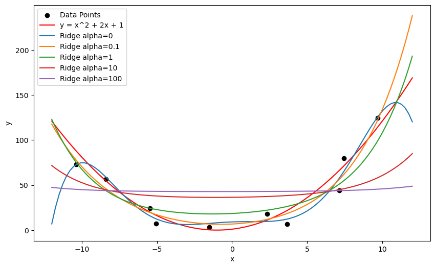

```python
import numpy as np
from sklearn.linear_model import Ridge
from sklearn.preprocessing import PolynomialFeatures, StandardScaler, MinMaxScaler
from sklearn.pipeline import make_pipeline
import matplotlib.pyplot as plt

def generate_polynomials_for_diff_alphas():
    x_list = np.array([-10.38446879, -8.38394902, -5.47700112, -5.04337481, -1.50548227, 3.65324449, 2.32253022, 7.14588818, 7.44347003, 9.67771813]).reshape(-1, 1)
    y_list = np.array([73.21995367, 56.4250573, 24.15989601, 7.14325154, 3.45955269, 6.68448382, 17.93465674, 44.02585723, 79.55124013, 124.46649205]).reshape(-1, 1)

    # Generate original x values
    x_original = np.linspace(-12, 12, 100).reshape(-1, 1)

    # Generate y values based on the function y = x^2 + 2x + 1
    y_original = x_original**2 + 2*x_original + 1

    # Plot the original function and the data points
    plt.figure(figsize=(10, 6))
    plt.scatter(x_list, y_list, label='Data Points', color='black')
    plt.plot(x_original, y_original, label='y = x^2 + 2x + 1', color='red')

    ### your code here

    alphas = [0, 0.1, 1, 10, 100]
    poly_pipeline = make_pipeline(
        PolynomialFeatures(degree=6),
        MinMaxScaler()
    )
    x_list_scaled = poly_pipeline.fit_transform(x_list)
    x_original_scaled = poly_pipeline.transform(x_original)

    for alpha in alphas:
        model = Ridge(alpha=alpha)
        model.fit(x_list_scaled, y_list)
        y_pred = model.predict(x_original_scaled)
        plt.plot(x_original, y_pred, label=f'Ridge alpha={alpha}')


    plt.xlabel('x')
    plt.ylabel('y')
    plt.legend()
    plt.show()

generate_polynomials_for_diff_alphas()
```

## (b) 10 points

We then give you a data generator that gives 10 data points around the function $y = x^2 + 2x + 1$ each time you run **data_gen()**.

We would like you to consider the bias and variance of a 6-degree polynomial classifier. In particular, for each of the regularization parameters $\alpha \in \{0,0.1,1,10,100\}$ we would like you to calculate the bias and variance over 1000 generated data sets from **data_gen()**.

To do so, you will need to calculate the bias and variance with respect to a particular data point. Please use $x^*=0, y^*=1$ for this data point.

For more context on how to calculate bias and variance, refer back to the slides from lecture 5.

**In addition**, briefly describe how the bias and variance change when the regularization parameter increases. If you are unable to finish the coding portion, please explain how you would expect bias and variance to change.

```python
def data_gen():
    # Number of data points
    n = 10

    # Generate original x values: you can choose the range and number of points
    x_original = np.linspace(-10, 10, n)

    # Generate y values based on the function y = x^2 + 2x + 1
    y_original = x_original**2 + 2*x_original + 1

    # Add some noise to x and y values
    noise_strength_x = 1.0  # Control the noise strength for x
    noise_strength_y = 5.0  # Control the noise strength for y

    x_noisy = x_original + noise_strength_x * np.random.randn(n)
    y_noisy = y_original + noise_strength_y * np.random.randn(n)

    return x_noisy, y_noisy


def calculate_bias_var():
    import numpy as np
    from sklearn.linear_model import LinearRegression

    bias_list = []
    variance_list = []

    # your code here
    alphas = [0, 0.1, 1, 10, 100]
    datasets = [data_gen() for _ in range(1000)]
    pipeline = make_pipeline(
        PolynomialFeatures(degree=6),
        MinMaxScaler()
    )
    for alpha in alphas:
        model_bias = []
        model_variance = []
        for dataset in datasets:
            x_original, y_original = dataset
            x_original = x_original.reshape(-1, 1)
            x_original_scaled = pipeline.fit_transform(x_original)
            model = Ridge(alpha=alpha)
            model.fit(x_original_scaled, y_original)
            y_pred = model.predict(x_original_scaled)
            bias = np.mean((y_original - y_pred) ** 2)
            variance = np.var(y_pred)
            model_bias.append(bias)
            model_variance.append(variance)
        bias_list.append(np.mean(model_bias))
        variance_list.append(np.mean(model_variance))
    return bias_list, variance_list

calculate_bias_var()
```

```
([np.float64(44.20316901280138),
  np.float64(103.02619660175057),
  np.float64(264.58572600335214),
  np.float64(948.8996804679945),
  np.float64(1397.8952112837346)],
 [np.float64(1430.3065773507665),
  np.float64(1228.243680495409),
  np.float64(705.988741204077),
  np.float64(75.29230159152863),
  np.float64(1.3066799725672673)])
```

**Your answer to Problem 5 here.** As the regularization term increases, the bias increases and variance decreases.

### Question 6 (15 points) Regression to the mean

Imagine you are working on a regression problem with six features.

You will:

1. Generate synthetic data.
2. Split data into training, validation, and test sets, with a ratio of 6:2:2
3. Train two different linear regression models (one with Ridge regularization term with $\alpha = 0.2$ and the other without).
4. Evaluate both models on the validation data with Mean Squared Error.
5. Suppose that for each time you will apply the "better" model according to the MSE on the validation data, evaluate it on the test data.

Repeat this 1000 times. Each time calculate the average of the error of the "better" model on validation data and test data respectively (so you will only record the error of the better model on the validation data, and the error of this same model on the test data.

Which average error is smaller? Why do you expect this (or not expect this)?

```python
import numpy as np
from sklearn.linear_model import LinearRegression, Ridge
from sklearn.model_selection import train_test_split
from sklearn.metrics import mean_squared_error

def answer_3():
    val_mse_list = []
    test_mse_list = []
    for _ in range(1000):

        # Generate synthetic data
        X = 2 * np.random.rand(50, 6)  # 50 samples, 6 features
        y = 10 + np.dot(X, np.array([3, 5, 2, 0, 0, 0])) + 2 * np.random.randn(50)

        # Your code here
        # Split data into training, validation, and test sets, with a ratio of 6:2:2
        X_train, X_temp, y_train, y_temp = train_test_split(X, y, test_size=0.4, random_state=42)
        X_val, X_test, y_val, y_test = train_test_split(X_temp, y_temp, test_size=0.5, random_state=42)

        # Train two models
        # Model 1: Linear Regression
        linear_model = LinearRegression().fit(X_train, y_train)

        # Model 2: Ridge Regression with alpha = 0.2
        ridge_model = Ridge(alpha=0.2).fit(X_train, y_train)

        # Evaluate on validation set
        val_mse1 = mean_squared_error(y_val, linear_model.predict(X_val))
        val_mse2 = mean_squared_error(y_val, ridge_model.predict(X_val))

        print(f"Validation MSE for Linear Regression: {val_mse1}")
        print(f"Validation MSE for Ridge Regression: {val_mse2}")

        # Choose the "better" model based on validation MSE
        better_model = linear_model if val_mse1 < val_mse2 else ridge_model
        val_mse_list.append(min(val_mse1, val_mse2))
        # Evaluate 'better' model on the test set
        test_mse = mean_squared_error(y_test, better_model.predict(X_test))
        test_mse_list.append(test_mse)
        #print(f"Test MSE for the 'better' model: {test_mse}")
    return np.mean(val_mse_list), np.mean(test_mse_list)

answer_3()
```

[output not shown]

[output cut: 1945 more lines]

[output not shown]

```
(np.float64(5.276546419406722), np.float64(5.257389690129041))
```

### Preliminary for Q7 and Q8

Before continuitng on to the next question, run the following block to set up the variables needed for later sections. It generates training and test data that we're going to use to fit a non-linear function (as opposed to the traditional linear regression problems you saw in the previous questions).

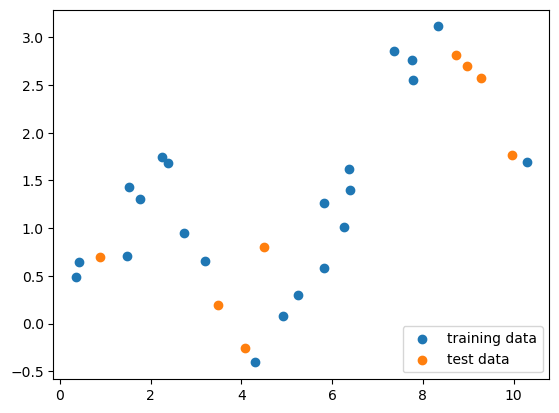

```python
import pandas as pd
from sklearn.model_selection import train_test_split
import numpy as np

np.random.seed(0)
n = 30
x = np.linspace(0, 10, n) + np.random.randn(n) / 5
y = np.sin(x) + x / 4 + np.random.randn(n) / 3


X_train, X_test, y_train, y_test = train_test_split(x, y, random_state=0)

# You can use this function to help you visualize the dataset by
# plotting a scatterplot of the data points
# in the training and test sets.
def part1_scatter():
    import matplotlib.pyplot as plt
    %matplotlib inline
    plt.figure()
    plt.scatter(X_train, y_train, label='training data')
    plt.scatter(X_test, y_test, label='test data')
    plt.legend(loc=4);


part1_scatter()  # let's plot the training and test data for the upcoming questions.
```

### Question 7 (10 points)

Write a function that fits a polynomial curve to the data, by using a polynomial LinearRegression model on the *training data* `X_train` for degrees 1, 3, 6, and 9. (Recall that we use PolynomialFeatures in sklearn.preprocessing to create the polynomial features and then fit a linear regression model to those extended features). For each model, find 100 predicted values over the interval x = 0 to 10 (e.g. `np.linspace(0,10,100)`) and store this in a numpy array. The first row of this array should correspond to the output from the model trained on degree 1, the second row degree 3, the third row degree 6, and the fourth row degree 9.

Note that you can run the `plot_two()` function to see the fitted curves on top of the dataset.

*This function should return a numpy array with shape `(4, 100)`*

```python
def answer_two():
    from sklearn.linear_model import LinearRegression
    from sklearn.preprocessing import PolynomialFeatures

    answer_array = []
    degree_list = [1, 3, 6, 9]
    X_pred = np.linspace(0, 10, 100).reshape(-1, 1)  # Generate predictions once

    for degree in degree_list:
        pipeline = make_pipeline(
            PolynomialFeatures(degree=degree),
            MinMaxScaler()
        )
        X_train_poly = pipeline.fit_transform(X_train.reshape(-1, 1))
        model = LinearRegression().fit(X_train_poly, y_train)
        X_pred_poly = pipeline.transform(X_pred)
        y_pred = model.predict(X_pred_poly)
        answer_array.append(y_pred)

    return np.vstack(answer_array)

answer_two()
```

```
array([[ 0.49947299,  0.51663261,  0.53379223,  0.55095185,  0.56811148,
         0.5852711 ,  0.60243072,  0.61959034,  0.63674996,  0.65390958,
         0.6710692 ,  0.68822883,  0.70538845,  0.72254807,  0.73970769,
         0.75686731,  0.77402693,  0.79118655,  0.80834617,  0.8255058 ,
         0.84266542,  0.85982504,  0.87698466,  0.89414428,  0.9113039 ,
         0.92846352,  0.94562315,  0.96278277,  0.97994239,  0.99710201,
         1.01426163,  1.03142125,  1.04858087,  1.06574049,  1.08290012,
         1.10005974,  1.11721936,  1.13437898,  1.1515386 ,  1.16869822,
         1.18585784,  1.20301747,  1.22017709,  1.23733671,  1.25449633,
         1.27165595,  1.28881557,  1.30597519,  1.32313482,  1.34029444,
         1.35745406,  1.37461368,  1.3917733 ,  1.40893292,  1.42609254,
         1.44325216,  1.46041179,  1.47757141,  1.49473103,  1.51189065,
         1.52905027,  1.54620989,  1.56336951,  1.58052914,  1.59768876,
         1.61484838,  1.632008  ,  1.64916762,  1.66632724,  1.68348686,
         1.70064648,  1.71780611,  1.73496573,  1.75212535,  1.76928497,
         1.78644459,  1.80360421,  1.82076383,  1.83792346,  1.85508308,
         1.8722427 ,  1.88940232,  1.90656194,  1.92372156,  1.94088118,
         1.9580408 ,  1.97520043,  1.99236005,  2.00951967,  2.02667929,
         2.04383891,  2.06099853,  2.07815815,  2.09531778,  2.1124774 ,
         2.12963702,  2.14679664,  2.16395626,  2.18111588,  2.1982755 ],
       [ 1.51170901,  1.4413091 ,  1.37428932,  1.31059585,  1.25017485,
         1.19297248,  1.13893491,  1.08800829,  1.0401388 ,  0.99527259,
         0.95335584,  0.9143347 ,  0.87815535,  0.84476393,  0.81410663,
         0.7861296 ,  0.760779  ,  0.73800101,  0.71774178,  0.69994748,
         0.68456427,  0.67153832,  0.66081579,  0.65234284,  0.64606565,
         0.64193037,  0.63988316,  0.6398702 ,  0.64183764,  0.64573165,
         0.6514984 ,  0.65908405,  0.66843475,  0.67949669,  0.69221601,
         0.70653889,  0.72241148,  0.73977996,  0.75859049,  0.77878923,
         0.80032234,  0.82313599,  0.84717635,  0.87238957,  0.89872182,
         0.92611927,  0.95452808,  0.98389441,  1.01416443,  1.0452843 ,
         1.07720019,  1.10985826,  1.14320467,  1.17718559,  1.21174719,
         1.24683562,  1.28239705,  1.31837764,  1.35472357,  1.39138099,
         1.42829606,  1.46541496,  1.50268384,  1.54004887,  1.57745621,
         1.61485203,  1.6521825 ,  1.68939377,  1.72643201,  1.76324338,
         1.79977405,  1.83597019,  1.87177795,  1.9071435 ,  1.942013  ,
         1.97633263,  2.01004853,  2.04310689,  2.07545385,  2.10703559,
         2.13779827,  2.16768805,  2.1966511 ,  2.22463359,  2.25158166,
         2.2774415 ,  2.30215926,  2.32568111,  2.34795321,  2.36892173,
         2.38853283,  2.40673267,  2.42346742,  2.43868324,  2.4523263 ,
         2.46434276,  2.47467878,  2.48328054,  2.49009419,  2.49506589],
```

[output cut: 25 more lines]

```
         1.42851065,  1.3349516 ,  1.22517773,  1.1022969 ,  0.96958809,
         0.83040907,  0.68811046,  0.54595733,  0.40705909,  0.27430851,
         0.15033008,  0.03743826, -0.06239454, -0.14756016, -0.21682739,
        -0.26934546, -0.30463892, -0.32259438, -0.32343998, -0.30771822,
        -0.2762531 , -0.23011262, -0.17056732, -0.09904625, -0.01709109,
         0.07369028,  0.17166985,  0.27524415,  0.38287633,  0.493135  ,
         0.6047285 ,  0.71653416,  0.82762146,  0.93726853,  1.0449714 ,
         1.15044557,  1.25361945,  1.35461961,  1.45374767,  1.55144904,
         1.64827386,  1.74483049,  1.84173237,  1.9395392 ,  2.03869349,
         2.13945395,  2.24182738,  2.34550098,  2.44977726,  2.5535141 ,
         2.65507276,  2.75227698,  2.84238657,  2.92208948,  2.98751631,
         3.03428194,  3.05755926,  3.05219011,  3.01283944,  2.93419871,
         2.81124505,  2.63956348,  2.41573944,  2.13782974,  1.80592048,
         1.42278068,  0.99462135,  0.53196987,  0.05067027, -0.42697946,
        -0.87094147, -1.24199118, -1.49009666, -1.55261095, -1.35226302]])
```

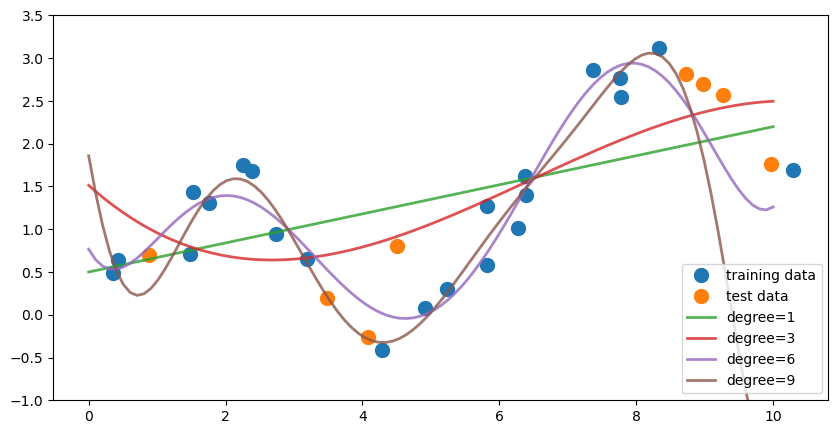

```python
# feel free to use the function part1_scatter() to replicate the figure
# from the prompt once you have completed question one
def plot_two(degree_predictions):
    import matplotlib.pyplot as plt
    %matplotlib inline
    plt.figure(figsize=(10,5))
    plt.plot(X_train, y_train, 'o', label='training data', markersize=10)
    plt.plot(X_test, y_test, 'o', label='test data', markersize=10)
    for i,degree in enumerate([1,3,6,9]):
        plt.plot(np.linspace(0,10,100), degree_predictions[i], alpha=0.8, lw=2, label='degree={}'.format(degree))
    plt.ylim(-1,3.5)
    plt.legend(loc=4)

plot_two(answer_two())
```

### Question 8 (10 points)

Write a function that fits a polynomial LinearRegression model on the training data `X_train` for degrees 0 through 9. For each model compute the $R^2$ (coefficient of determination) regression score on the training data as well as the the test data, and return both of these arrays in a tuple.

Based on the $R^2$ scores above (degree levels 0 through 9), what degree level corresponds to a model that is underfitting? What degree level corresponds to a model that is overfitting? What choice of degree level would provide a model with good generalization performance on this dataset? Note: there may be multiple correct solutions to this question.

(Hint: you can plot the r2_train and r2_test vs the degree to investigate underfitting/overfitting.)

*This function should return one tuple of numpy arrays `(r2_train, r2_test, Underfitting, Good_Generalization, Overfitting)`, where both `r2_train` and `r2_test` should have shape `(10,)`, and `Underfitting, Good_Generalization, Overfitting` should be three lists of int partitioning 0-9.*

```python
def answer_three():
    from sklearn.linear_model import LinearRegression
    from sklearn.preprocessing import PolynomialFeatures
    r2_train, r2_test = [], []
    Underfitting, Good_Generalization, Overfitting = [], [], []

    # Your code here
    for degree in range(10):
        pipeline = make_pipeline(
            PolynomialFeatures(degree=degree),
            MinMaxScaler()
        )
        X_train_poly = pipeline.fit_transform(X_train.reshape(-1, 1))
        X_test_poly = pipeline.transform(X_test.reshape(-1, 1))
        model = LinearRegression().fit(X_train_poly, y_train)
        r2_train_score = model.score(X_train_poly, y_train)
        r2_test_score = model.score(X_test_poly, y_test)
        r2_train.append(r2_train_score)
        r2_test.append(r2_test_score)
        Underfitting = [0, 1, 2, 3]
        Good_Generalization = [4, 5, 6, 8]
        Overfitting = [7, 9]
    return (r2_train, r2_test, Underfitting, Good_Generalization, Overfitting)

answer_three()
```

```
([0.0,
  0.2643975500223753,
  0.32742357618463,
  0.3722012635797515,
  0.8673604496714555,
  0.8714478477112108,
  0.913357440948628,
  0.9365234357860431,
  0.9384067915708731,
  0.9406850610895372],
 [-0.010639689448016743,
  0.5404084766379272,
  0.6426655069520221,
  0.7638109083466661,
  0.6592259101695964,
  0.7573712228485813,
  0.7713032363645259,
  0.38779951683191305,
  0.8104206433151161,
  -0.5929433096153114],
 [0, 1, 2, 3],
 [4, 5, 6, 8],
 [7, 9])
```

## Disclosure

**If you used ChatGPT for any of the questions above, please disclose which questions you used it for, and how you used it.**

**Disclosure here:**